# jekyll-jupyter-notebook20261007-3382-kxh01d

### Part 2: KNN for Classification with Scikit-learn (Synthetic Data)

Let's use `scikit-learn` to implement `KNeighborsClassifier` on a synthetic dataset and visualize its decision boundaries.

**Tasks:**

- Create a 2D synthetic dataset with multiple classes.
- Visualize the data points.
- Train a `KNeighborsClassifier` model.
- Plot the decision boundaries learned by the model for different 'K' values.
- Make predictions.

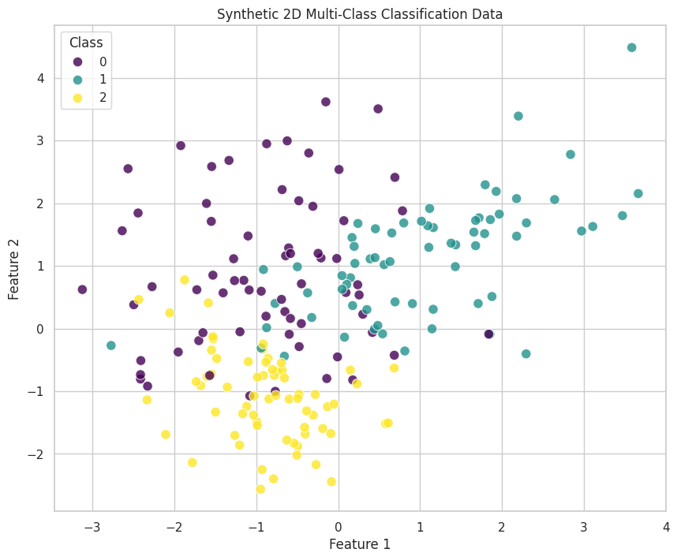

```python
# --- 2.1 Create a 2D synthetic dataset ---
X_clf, y_clf = make_classification(n_samples=200, n_features=2, n_redundant=0,
                                   n_informative=2, n_clusters_per_class=1,
                                   random_state=42, n_classes=3) # 3 classes for better visualization

# Convert to DataFrame for easier plotting
df_clf = pd.DataFrame(X_clf, columns=['Feature_1', 'Feature_2'])
df_clf['Target'] = y_clf

# --- 2.2 Visualize the data points ---
plt.figure(figsize=(10, 8))
sns.scatterplot(data=df_clf, x='Feature_1', y='Feature_2', hue='Target', palette='viridis', s=80, alpha=0.8)
plt.title('Synthetic 2D Multi-Class Classification Data')
plt.xlabel('Feature 1')
plt.ylabel('Feature 2')
plt.legend(title='Class')
plt.show()
```

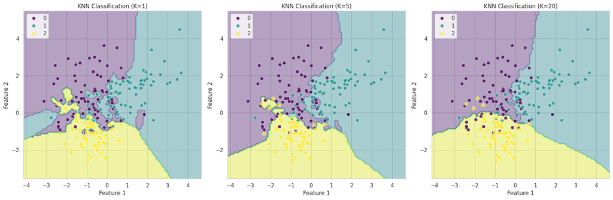

```python
# --- 2.3 Train a KNeighborsClassifier model and plot decision boundaries ---
def plot_decision_boundary(X, y, model, title, ax):
    x_min, x_max = X[:, 0].min() - 1, X[:, 0].max() + 1
    y_min, y_max = X[:, 1].min() - 1, X[:, 1].max() + 1
    xx, yy = np.meshgrid(np.linspace(x_min, x_max, 100),
                         np.linspace(y_min, y_max, 100))

    Z = model.predict(np.c_[xx.ravel(), yy.ravel()])
    Z = Z.reshape(xx.shape)

    ax.contourf(xx, yy, Z, alpha=0.4, cmap=plt.cm.viridis)
    sns.scatterplot(x=X[:, 0], y=X[:, 1], hue=y, palette='viridis', s=50, alpha=0.8, ax=ax)
    ax.set_title(title)
    ax.set_xlabel('Feature 1')
    ax.set_ylabel('Feature 2')

fig, axes = plt.subplots(1, 3, figsize=(18, 6))

# K = 1
knn_k1 = KNeighborsClassifier(n_neighbors=1)
knn_k1.fit(X_clf, y_clf)
plot_decision_boundary(X_clf, y_clf, knn_k1, 'KNN Classification (K=1)', axes[0])

# K = 5
knn_k5 = KNeighborsClassifier(n_neighbors=5)
knn_k5.fit(X_clf, y_clf)
plot_decision_boundary(X_clf, y_clf, knn_k5, 'KNN Classification (K=5)', axes[1])

# K = 20
knn_k20 = KNeighborsClassifier(n_neighbors=20)
knn_k20.fit(X_clf, y_clf)
plot_decision_boundary(X_clf, y_clf, knn_k20, 'KNN Classification (K=20)', axes[2])

plt.tight_layout()
plt.show()
```

```python
# --- 2.4 Make predictions ---
sample_new_point = np.array([[0.5, 0.5]])
predicted_class = knn_k5.predict(sample_new_point)[0]
print(f"\nNew sample point {sample_new_point[0]} is predicted to be in Class: {predicted_class} (with K=5)")
print(f"Probabilities (K=5): {knn_k5.predict_proba(sample_new_point)[0]}")
```

```
New sample point [0.5 0.5] is predicted to be in Class: 0 (with K=5)
Probabilities (K=5): [0.6 0.4 0. ]
```

**Discussion Point:**

- Compare the decision boundaries for K=1, K=5, and K=20. How does changing K affect the smoothness and complexity of the boundaries?
- What are the potential risks of using a very small K (e.g., K=1) in a noisy dataset?

### Part 3: KNN for Classification (Real-world Data) & Feature Scaling

For distance-based algorithms like KNN, **feature scaling is critically important**. If features have vastly different scales (e.g., one feature ranges from 0-1000 and another from 0-1), the feature with the larger range will disproportionately influence the distance calculation, making the "closeness" metric biased.

We'll use the Wine dataset, which describes wines by various chemical properties and classifies them into three types.

**Tasks:**

- Load the Wine dataset.
- Perform initial data exploration.
- Split data.
- **Demonstrate KNN performance *without* scaling.**
- **Demonstrate KNN performance *with* `StandardScaler`.**
- Compare evaluation metrics (accuracy, classification report) with and without scaling.
- Explain *why* feature scaling is critical for distance-based algorithms.

```python
# --- 3.1 Load the Wine dataset ---
wine = load_wine()
X_wine = pd.DataFrame(wine.data, columns=wine.feature_names)
y_wine = pd.Series(wine.target)

print(f"\nDataset loaded. Number of features: {X_wine.shape[1]}")
print(f"Target classes: {wine.target_names}")

# --- 3.2 Initial data exploration ---
print("\n--- X_wine Head ---")
print(X_wine.head())
print("\n--- X_wine Info ---")
X_wine.info()
print("\n--- X_wine Describe ---")
print(X_wine.describe()) # Notice the wide range of scales!

print("\n--- Target (y_wine) Value Counts ---")
print(y_wine.value_counts())

# --- 3.3 Split data into training and testing sets ---
X_train_raw, X_test_raw, y_train, y_test = train_test_split(X_wine, y_wine, test_size=0.3, random_state=42, stratify=y_wine)

print(f"\nTraining set X shape: {X_train_raw.shape}, y shape: {y_train.shape}")
print(f"Testing set X shape: {X_test_raw.shape}, y shape: {y_test.shape}")

# --- 3.4 Demonstrate KNN performance *without* scaling ---
print("\n### KNN Classification WITHOUT Feature Scaling ###")
knn_no_scale = KNeighborsClassifier(n_neighbors=5) # Using K=5
knn_no_scale.fit(X_train_raw, y_train)
y_pred_no_scale = knn_no_scale.predict(X_test_raw)

print(f"Accuracy (No Scaling): {accuracy_score(y_test, y_pred_no_scale):.4f}")
print("\nClassification Report (No Scaling):")
print(classification_report(y_test, y_pred_no_scale, target_names=wine.target_names))

# --- 3.5 Demonstrate KNN performance *with* StandardScaler ---
print("\n### KNN Classification WITH Feature Scaling ###")
scaler = StandardScaler()
X_train_scaled = scaler.fit_transform(X_train_raw)
X_test_scaled = scaler.transform(X_test_raw)

knn_scaled = KNeighborsClassifier(n_neighbors=5) # Using K=5
knn_scaled.fit(X_train_scaled, y_train)
y_pred_scaled = knn_scaled.predict(X_test_scaled)

print(f"Accuracy (With Scaling): {accuracy_score(y_test, y_pred_scaled):.4f}")
print("\nClassification Report (With Scaling):")
print(classification_report(y_test, y_pred_scaled, target_names=wine.target_names))

# --- 3.6 Compare evaluation metrics ---
print("\n--- Comparison ---")
print(f"Accuracy improved from {accuracy_score(y_test, y_pred_no_scale):.4f} to {accuracy_score(y_test, y_pred_scaled):.4f} after scaling.")
print("This clearly shows the positive impact of feature scaling on KNN's performance.")
```

```
Dataset loaded. Number of features: 13
Target classes: ['class_0' 'class_1' 'class_2']

--- X_wine Head ---
   alcohol  malic_acid   ash  alcalinity_of_ash  magnesium  total_phenols  \
0    14.23        1.71  2.43               15.6      127.0           2.80
1    13.20        1.78  2.14               11.2      100.0           2.65
2    13.16        2.36  2.67               18.6      101.0           2.80
3    14.37        1.95  2.50               16.8      113.0           3.85
4    13.24        2.59  2.87               21.0      118.0           2.80

   flavanoids  nonflavanoid_phenols  proanthocyanins  color_intensity   hue  \
0        3.06                  0.28             2.29             5.64  1.04
1        2.76                  0.26             1.28             4.38  1.05
2        3.24                  0.30             2.81             5.68  1.03
3        3.49                  0.24             2.18             7.80  0.86
4        2.69                  0.39             1.82             4.32  1.04

   od280/od315_of_diluted_wines  proline
0                          3.92   1065.0
1                          3.40   1050.0
2                          3.17   1185.0
3                          3.45   1480.0
4                          2.93    735.0

--- X_wine Info ---
<class 'pandas.core.frame.DataFrame'>
RangeIndex: 178 entries, 0 to 177
Data columns (total 13 columns):
 #   Column                        Non-Null Count  Dtype
---  ------                        --------------  -----
 0   alcohol                       178 non-null    float64
 1   malic_acid                    178 non-null    float64
 2   ash                           178 non-null    float64
 3   alcalinity_of_ash             178 non-null    float64
 4   magnesium                     178 non-null    float64
 5   total_phenols                 178 non-null    float64
 6   flavanoids                    178 non-null    float64
 7   nonflavanoid_phenols          178 non-null    float64
 8   proanthocyanins               178 non-null    float64
```

[output cut: 65 more lines]

```
Classification Report (With Scaling):
              precision    recall  f1-score   support

     class_0       1.00      1.00      1.00        18
     class_1       1.00      0.86      0.92        21
     class_2       0.83      1.00      0.91        15

    accuracy                           0.94        54
   macro avg       0.94      0.95      0.94        54
weighted avg       0.95      0.94      0.94        54


--- Comparison ---
Accuracy improved from 0.7222 to 0.9444 after scaling.
This clearly shows the positive impact of feature scaling on KNN's performance.
```

**Discussion Point:**

- Based on the `X_wine.describe()` output, identify features with vastly different scales. How might this have affected the KNN model without scaling?
- Explain in your own words why `StandardScaler` (or `MinMaxScaler`) is so important for KNN.

### Part 4: Optimizing 'K' - Choosing the Best Number of Neighbors

Choosing an appropriate value for 'K' is crucial for KNN's performance. A common approach is to test a range of 'K' values and select the one that yields the best performance, typically using cross-validation to get a more robust estimate.

**Tasks:**

- Explain the trade-off: small K (noisy, overfitting) vs. large K (smoothed, underfitting).
- Demonstrate a simple method to find optimal 'K' using a loop and cross-validation on accuracy.
- Plot accuracy/error rate vs. K.

```
K=1: Mean CV Accuracy = 0.9513
K=3: Mean CV Accuracy = 0.9593
K=5: Mean CV Accuracy = 0.9673
K=7: Mean CV Accuracy = 0.9673
K=9: Mean CV Accuracy = 0.9513
K=11: Mean CV Accuracy = 0.9757
K=13: Mean CV Accuracy = 0.9673
K=15: Mean CV Accuracy = 0.9673
K=17: Mean CV Accuracy = 0.9673
K=19: Mean CV Accuracy = 0.9593

Optimal K found: 11 with mean CV accuracy of 0.9757
```

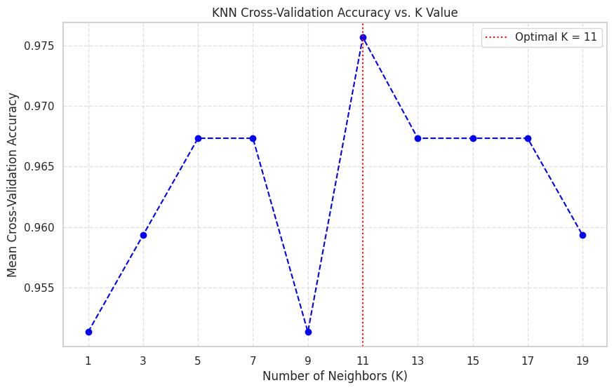

```
Trade-offs in choosing 'K':
- Small K (e.g., K=1): Captures fine details, sensitive to noise/outliers (high variance, potential overfitting).
- Large K: Smoother decision boundary, less sensitive to noise, may over-generalize (high bias, potential underfitting).
- Generally, an odd K is preferred for binary classification to avoid ties.
```

```python
# --- Demonstrate finding optimal 'K' using cross-validation ---
k_values = list(range(1, 20, 2)) # Test odd K values from 1 to 19
cv_scores = []

for k in k_values:
    knn = KNeighborsClassifier(n_neighbors=k)
    # Perform 5-fold cross-validation and store the mean accuracy
    scores = cross_val_score(knn, X_train_scaled, y_train, cv=5, scoring='accuracy')
    cv_scores.append(scores.mean())
    print(f"K={k}: Mean CV Accuracy = {scores.mean():.4f}")

# Find the optimal K
optimal_k_index = np.argmax(cv_scores)
optimal_k = k_values[optimal_k_index]
print(f"\nOptimal K found: {optimal_k} with mean CV accuracy of {cv_scores[optimal_k_index]:.4f}")

# --- Plot accuracy vs. K ---
plt.figure(figsize=(10, 6))
plt.plot(k_values, cv_scores, marker='o', linestyle='--', color='blue')
plt.title('KNN Cross-Validation Accuracy vs. K Value')
plt.xlabel('Number of Neighbors (K)')
plt.ylabel('Mean Cross-Validation Accuracy')
plt.xticks(k_values)
plt.grid(True, linestyle='--', alpha=0.6)
plt.axvline(x=optimal_k, color='red', linestyle=':', label=f'Optimal K = {optimal_k}')
plt.legend()
plt.show()


# --- Explain trade-offs ---
print("\nTrade-offs in choosing 'K':")
print("- Small K (e.g., K=1): Captures fine details, sensitive to noise/outliers (high variance, potential overfitting).")
print("- Large K: Smoother decision boundary, less sensitive to noise, may over-generalize (high bias, potential underfitting).")
print("- Generally, an odd K is preferred for binary classification to avoid ties.")
```

**Discussion Point:**

- Why is cross-validation (e.g., `cross_val_score`) used instead of just training on `X_train_scaled` and testing on `X_test_scaled` to find the optimal K?
- What does the plot of accuracy vs. K tell you about the model's behavior as K changes?

### Part 5: KNN for Regression with Scikit-learn

KNN can also be used for regression tasks, where the output is a continuous numerical value. Instead of majority voting for classes, it takes the average (or median) of the target values of its K nearest neighbors.

**Tasks:**

- Create a simple regression dataset.
- Split data and scale.
- Train a `KNeighborsRegressor` model.
- Evaluate using regression metrics (MAE, MSE, RMSE, R-squared).
- Discuss the difference in prediction logic for regression (averaging).

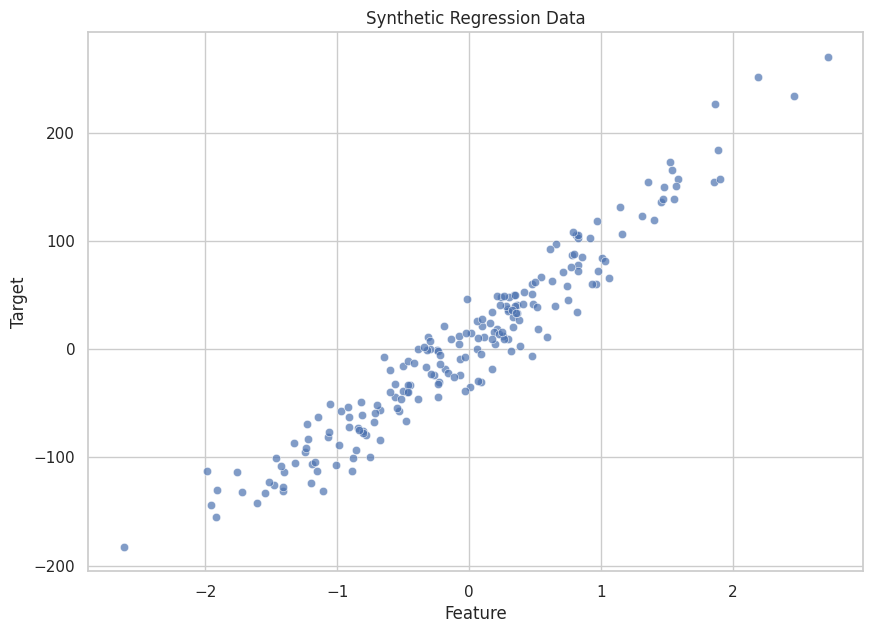

```
KNeighborsRegressor model trained successfully!
```

```python
# --- 5.1 Create a simple regression dataset ---
# Make a more complex, non-linear relationship to show KNN's flexibility
X_reg, y_reg = make_regression(n_samples=200, n_features=1, noise=20, random_state=42)
# Introduce a slight non-linearity
y_reg = y_reg + (X_reg[:,0]**2) * 5

# Reshape X_reg for single feature regression model compatibility
X_reg = X_reg.reshape(-1, 1)

plt.figure(figsize=(10, 7))
sns.scatterplot(x=X_reg[:, 0], y=y_reg, alpha=0.7)
plt.title('Synthetic Regression Data')
plt.xlabel('Feature')
plt.ylabel('Target')
plt.show()

# --- 5.2 Split data and scale ---
X_train_reg, X_test_reg, y_train_reg, y_test_reg = train_test_split(X_reg, y_reg, test_size=0.3, random_state=42)

scaler_reg = StandardScaler()
X_train_reg_scaled = scaler_reg.fit_transform(X_train_reg)
X_test_reg_scaled = scaler_reg.transform(X_test_reg)

# --- 5.3 Train a KNeighborsRegressor model ---
knn_reg = KNeighborsRegressor(n_neighbors=5) # Choose a K value
knn_reg.fit(X_train_reg_scaled, y_train_reg)

print("\nKNeighborsRegressor model trained successfully!")

# --- 5.4 Make predictions ---
y_pred_reg = knn_reg.predict(X_test_reg_scaled)
```

```python
# --- 5.5 Evaluate using regression metrics ---
mae_reg = mean_absolute_error(y_test_reg, y_pred_reg)
mse_reg = mean_squared_error(y_test_reg, y_pred_reg)
rmse_reg = np.sqrt(mse_reg)
r2_reg = r2_score(y_test_reg, y_pred_reg)

print(f"\nMean Absolute Error (MAE): {mae_reg:.4f}")
print(f"Mean Squared Error (MSE): {mse_reg:.4f}")
print(f"Root Mean Squared Error (RMSE): {rmse_reg:.4f}")
print(f"R-squared (R2): {r2_reg:.4f}")
```

```
Mean Absolute Error (MAE): 21.2281
Mean Squared Error (MSE): 800.2847
Root Mean Squared Error (RMSE): 28.2893
R-squared (R2): 0.9135
```

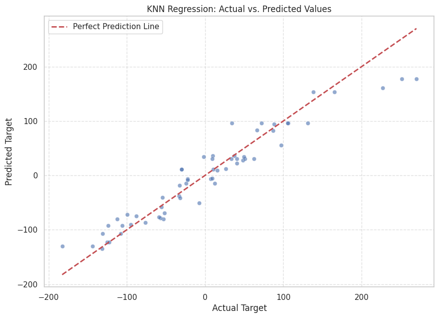

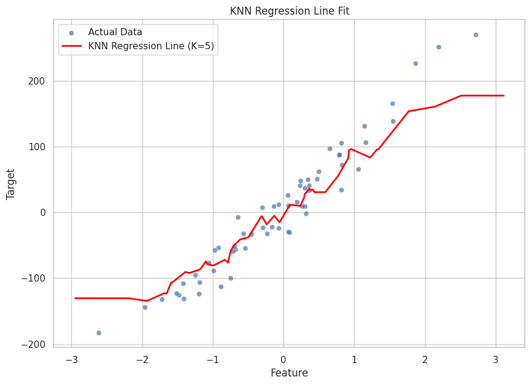

```python
# --- 5.6 Plot actual vs. predicted values ---
plt.figure(figsize=(10, 7))
sns.scatterplot(x=y_test_reg, y=y_pred_reg, alpha=0.6)
plt.plot([y_test_reg.min(), y_test_reg.max()], [y_test_reg.min(), y_test_reg.max()], 'r--', lw=2, label='Perfect Prediction Line')
plt.xlabel('Actual Target')
plt.ylabel('Predicted Target')
plt.title('KNN Regression: Actual vs. Predicted Values')
plt.grid(True, linestyle='--', alpha=0.6)
plt.legend()
plt.show()

# Plot the regression line with original data for a single feature
# To visualize the regression line, we'll sort the test features
# and predict on them.
sorted_indices = np.argsort(X_test_reg_scaled.flatten())
X_test_reg_scaled_sorted = X_test_reg_scaled[sorted_indices] # Corrected line
y_pred_reg_sorted = knn_reg.predict(X_test_reg_scaled_sorted)

plt.figure(figsize=(10, 7))
sns.scatterplot(x=X_test_reg.flatten(), y=y_test_reg, alpha=0.7, label='Actual Data')
plt.plot(X_test_reg_scaled_sorted.flatten(), y_pred_reg_sorted, color='red', linestyle='-', linewidth=2, label='KNN Regression Line (K=5)')
plt.title('KNN Regression Line Fit')
plt.xlabel('Feature')
plt.ylabel('Target')
plt.legend()
plt.show()
```

**Discussion Point:**

- How does KNN make a prediction for a new data point in a regression problem?
- How might the choice of K affect the smoothness of the regression line?

### Part 6: Advantages, Disadvantages, and Use Cases

KNN is a straightforward and intuitive algorithm, but it has specific characteristics that make it suitable for some tasks and less ideal for others.

**Advantages:**

1. **Simplicity and Interpretability:** The algorithm is easy to understand and implement. Its decisions are relatively transparent: a data point is classified based on its closest neighbors.
2. **No Strong Assumptions:** KNN is a non-parametric algorithm, meaning it does not make strong assumptions about the underlying data distribution (unlike linear or logistic regression, which assume linearity). This makes it flexible for various data types.
3. **Handles Non-linear Relationships:** Because it's based on local neighborhoods, KNN can model complex, non-linear decision boundaries effectively.
4. **Can be Used for Both Classification and Regression:** Its versatility makes it a good general-purpose tool.
5. **Effective for Low-Dimensional Data:** Performs well when the number of features is small.

**Disadvantages:**

1. **Computationally Expensive (at prediction time):** This is its biggest drawback. For every new prediction, KNN needs to calculate the distance to *all* training data points. This makes it very slow for large datasets, as the prediction time increases linearly with the number of training samples.
2. **Memory Intensive:** It needs to store the entire training dataset in memory for prediction, which can be an issue for very large datasets.
3. **Curse of Dimensionality:** As the number of features (dimensions) increases, the concept of "closeness" becomes less meaningful. Data points become sparse in high-dimensional space, and distances between points tend to become more uniform, making it harder to find truly "nearest" neighbors. This degrades performance significantly.
4. **Sensitive to Irrelevant Features:** If the dataset contains many irrelevant features, these features can disproportionately influence the distance calculation, even if they have no real predictive power. Feature selection or dimensionality reduction is often necessary.
5. **Sensitive to Feature Scale:** As demonstrated in Part 3, features with larger ranges can dominate the distance calculation, making scaling absolutely essential.
6. **Performance with Imbalanced Data:** If one class heavily outnumbers others, KNN might be biased towards predicting the majority class, even if the minority class is the one of interest. Techniques like weighted KNN (giving more weight to closer neighbors) or resampling can mitigate this.

**Common Use Cases:**

- **Recommendation Systems:** Finding similar users or items (e.g., "users who liked this also liked...").
- **Image Recognition:** Early applications in classifying images based on pixel similarity.
- **Handwritten Digit Recognition:** Classifying handwritten numbers.
- **Anomaly Detection:** Identifying unusual data points that are far from any cluster of known data.
- **Medical Diagnosis:** Classifying diseases based on patient symptoms and test results (with careful consideration of data balance).

Prepared By

**Md. Atikuzzaman**  
Lecturer  
Department of Computer Science and Engineering  
Green University of Bangladesh  
Email: atik@cse.green.edu.bd